# Homework_6_Jared_Lee

Jared Lee

7/12/2018

```r
library(tidyverse)
```

```r
library(mosaicData)
library(ggplot2)
```

## Exercise 1

### 1) What variables are in this data set?

Answer: outcome, smoker, age

### 2) How many observations are there and what does each represent?

Answer: 1,314 obervations representing individuals regarding survival status (dead, alive), smoker or nonsmoker, and age in years.

### 3) Create a table (use the R code below as a guide) and a visualization of the relationship between smoking status and outcome, ignoring age. What do you see? Does it make sense?

Answer: I would expect the number of deaths to be higher for smokers. Non-smoker death proportion is 31% vs 24% for smokers. I would say that it does not make sense.

```r
Whickham %>%
  count(smoker, outcome)
```

```
## # A tibble: 4 x 3
##   smoker outcome     n
##   <fct>  <fct>   <int>
## 1 No     Alive     502
## 2 No     Dead      230
## 3 Yes    Alive     443
## 4 Yes    Dead      139
```

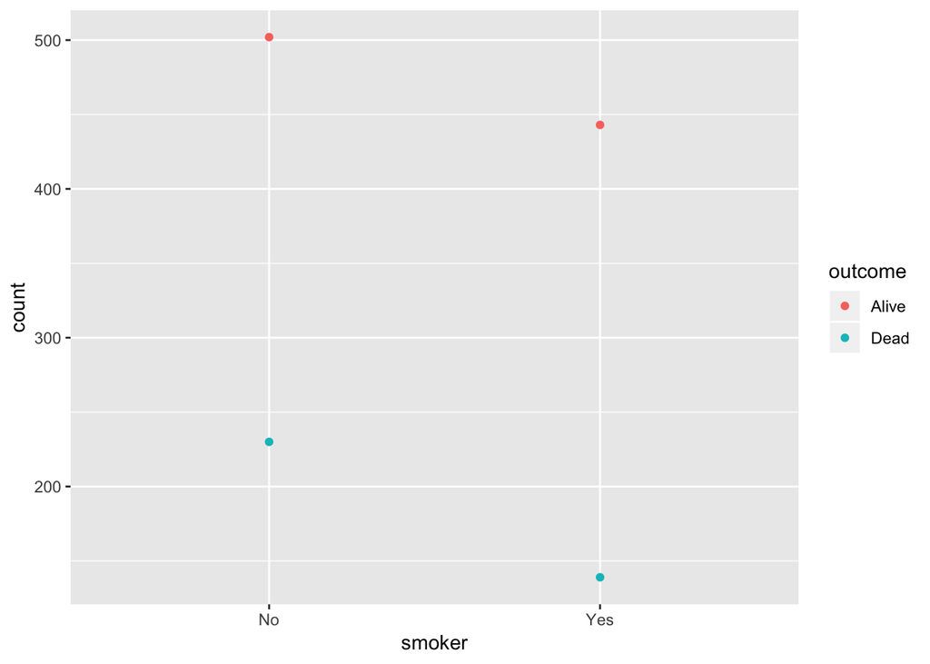

```r
Whickham %>%
  count(smoker, outcome) %>%
  ggplot() +
  geom_point(aes(smoker, n, color = outcome)) +
  ylab("count")
```

### 4)Recode the age variable into an ordered factor with three categories: age <= 44, age > 44 & age <= 64, and age > 64. Now, recreate visualization from above, but facet on your new age factor. What do you see? Does it make sense?

Answer: The number of deaths for the 65+ age group exceeds the alive numbers. This makes more sense as health symptoms may be accelorate a decline in health later in life.

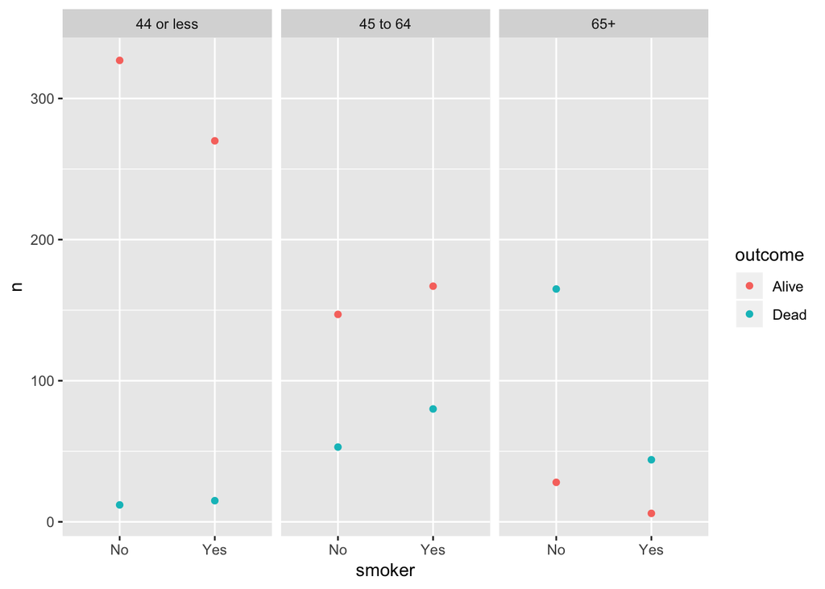

```r
Whickham_age <- Whickham %>% mutate(grp_age = case_when(age <= 44 ~ '44 or less',
                                                      age > 44 & age <= 64 ~ '45 to 64',
                                                      age > 64 ~ '65+'))

Whickham_age %>%
  count(smoker, outcome, grp_age) %>%
  ggplot() +
  geom_point(aes(smoker, n, color = outcome)) +
  facet_wrap(~grp_age)
```

## Exercise 2

### 1) Generate a random sample of size n = 10000 from a gamma(1,2) distribution and plot a histogram or density curve. Use the code below to help you get your sample.

```r
n <- 10000

# look at ?rgamma to read about this function
(gamma_samp <- tibble(x = rgamma(n, shape = 1, scale = 2)))
```

```
## # A tibble: 10,000 x 1
##         x
##     <dbl>
##  1 0.742
##  2 0.0900
##  3 0.509
##  4 1.07
##  5 0.674
##  6 0.396
##  7 1.20
##  8 0.334
##  9 0.820
## 10 2.14
## # ... with 9,990 more rows
```

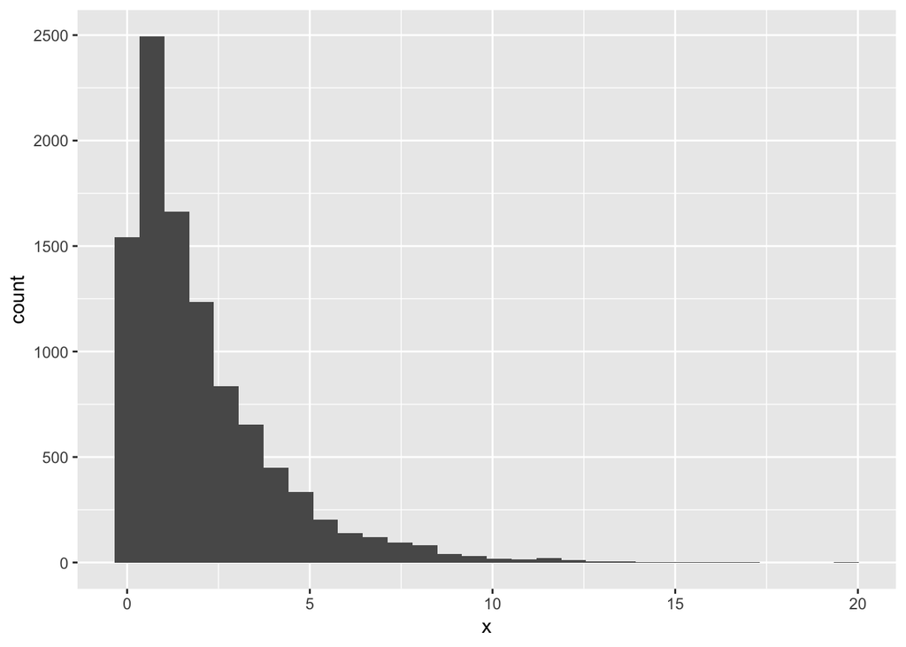

```r
gamma_samp %>%
  ggplot() +
  geom_histogram(aes(x))
```

```r
(mean_samp <- gamma_samp %>% .[['x']] %>% mean())
```

```
## [1] 2.025428
```

```r
(sd_samp <- gamma_samp %>% .[['x']] %>% sd())
```

```
## [1] 2.058339
```

### 3) Pretend the distribution of our population of data looks like the plot above. Now take a sample of size n = 30 from a Gamma(1,2) distribution, plot the histogram or density curve, and calculate the mean and standard deviation.

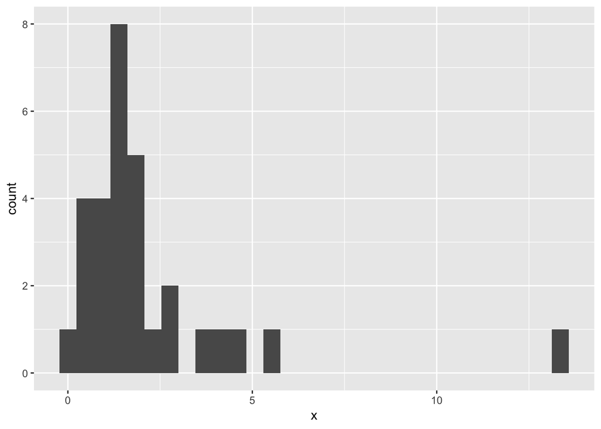

```r
samp30 <- gamma_samp %>%
  sample_n(30)

samp30 %>%
  ggplot() +
  geom_histogram(aes(x))
```

```r
(mean_samp1 <- samp30 %>% .[['x']] %>% mean())
```

```
## [1] 2.15475
```

```r
(sd_samp1 <- samp30 %>% .[['x']] %>% sd())
```

```
## [1] 2.483048
```

### 4) Take a sample of size n = 30, again from the Gamma(1,2) distribution, calculate the mean, and assign it to a vector named mean_samp. Repeat this 10000 times!!!! The code below might help.

```r
# create a vector with 10000 NAs
mean_samp2 <- rep(NA, 10000)

# start a loop
for(i in 1:10000) {
  g_samp <- rgamma(30, shape = 1, scale = 2)
  mean_samp2[i] <- mean(g_samp)
}
# Convert vector to a tibble
(mean_samp2 <- tibble(mean_samp2))
```

```
## # A tibble: 10,000 x 1
##    mean_samp2
##         <dbl>
##  1       2.15
##  2       2.13
##  3       2.00
##  4       2.56
##  5       1.87
##  6       2.12
##  7       1.41
##  8       2.32
##  9       2.35
## 10       1.85
## # ... with 9,990 more rows
```

```r
View(mean_samp2)
```

### 5) Make a histogram of your collection of means from above (mean_samp).

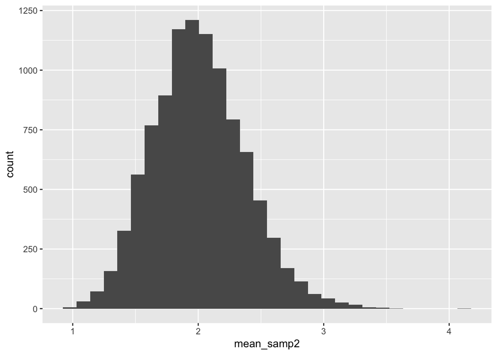

```r
mean_samp2 %>%
  ggplot() +
  geom_histogram((aes(mean_samp2)))
```

### 6) Calculate the mean and standard deviation of all of your sample means.

```r
(mean_a <- mean_samp2 %>% .[['mean_samp2']] %>% mean())
```

```
## [1] 2.006583
```

```r
(sd_a <- mean_samp2 %>% .[['mean_samp2']] %>% sd())
```

```
## [1] 0.3673965
```

### 7) Did anything surprise you about your answers to #6?

Answer: The SD is very low. Eariler it was closer to 2

### 8) Repeat #4-#6, but now with a sample of size n = 300 instead. Do your results match up well with the theorem?

Answer: Distribution is still normal.

```r
# create a vector with 10000 NAs
mean_samp2 <- rep(NA, 10000)

# start a loop
for(i in 1:10000) {
  g_samp <- rgamma(300, shape = 1, scale = 2)
  mean_samp2[i] <- mean(g_samp)
}

# Convert vector to a tibble
(mean_samp2 <- tibble(mean_samp2))
```

```
## # A tibble: 10,000 x 1
##    mean_samp2
##         <dbl>
##  1       1.92
##  2       1.98
##  3       2.08
##  4       2.00
##  5       1.94
##  6       1.94
##  7       1.95
##  8       2.13
##  9       1.98
## 10       1.80
## # ... with 9,990 more rows
```

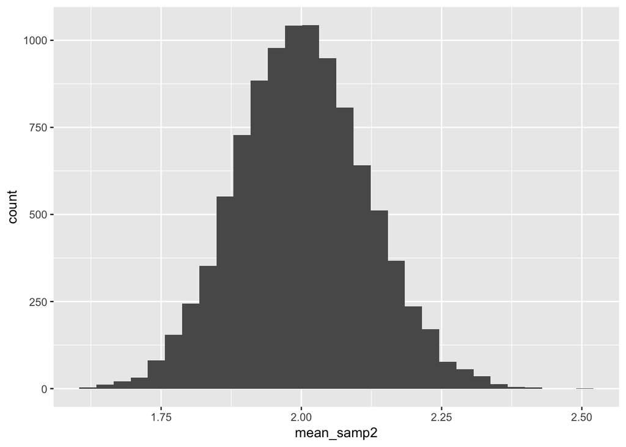

```r
View(mean_samp2)

#Histogram
mean_samp2 %>%
  ggplot() +
  geom_histogram((aes(mean_samp2)))
```

```r
#Find Mean and SD
(mean_a <- mean_samp2 %>% .[['mean_samp2']] %>% mean())
```

```
## [1] 2.000897
```

```r
(sd_a <- mean_samp2 %>% .[['mean_samp2']] %>% sd())
```

```
## [1] 0.1160531
```